# EP05 - Equipo 1

**Link IA:** https://share.gemini.google/gLVgzs2kDSKU

## La situación

El material particulado fino, MP2,5, son partículas de hasta 2,5 micrómetros que quedan suspendidas en el aire y que, al respirarlas, llegan hasta los pulmones. En Santiago su concentración sube en invierno, sobre todo en los días secos y sin viento, cuando una capa de aire más cálido en altura deja atrapado cerca del suelo el aire frío, y con él lo que se emite. El Sistema de Información Nacional de Calidad del Aire (SINCA), del Ministerio del Medio Ambiente, publica lo que miden sus estaciones de monitoreo, y con esos datos se puede preguntar, por ejemplo, si un invierno fue distinto de otro, o si en un mismo invierno el aire de una comuna fue distinto del de otra.

## La discusión con una IA (avance 1)

Elegimos una prueba ANOVA de 1 vía para muestras independientes ya que queremos comparar la media de variables independientes. Creemos que una forma de verificar las condiciones es asumir la independencia de las variables. Se realizará una verificación de normalidad mediante una prueba de Shapiro y una verificación de homogeneidad mediante la prueba de Levene.

Según los argumentos que la IA nos entrega, nuestros métodos no son completamente sólidos, ya que la prueba t es una prueba robusta frente a violaciones leves de normalidad cuando el tamaño de las muestras es relativamente grande, por lo que no sería estrictamente necesario realizar la prueba de Shapiro. La IA nos sugiere una prueba ANOVA de Welch: es una alternativa robusta al ANOVA tradicional que no asume varianzas iguales entre los grupos.

Sin embargo, nosotros continuaremos con la propuesta original, ya que el ANOVA estándar tiene mayor potencia matemáStica si se cumplen los supuestos, y validaremos la homocedasticidad empíricamente en lugar de asumir varianzas distintas desde el inicio.

## Pregunta 1

En la estación Las Condes, ¿la concentración diaria promedio de MP2,5 fue la misma en los inviernos de 2018, 2019, 2020 y 2021? En particular, interesa saber si el invierno de 2020, el de las cuarentenas por la pandemia, se diferenció del promedio de los demás inviernos. Si filtraron bien los datos, deberían obtener: 2018, n = 22 y media 25,91; 2019, n = 21 y media 24,05; 2020, n = 23 y media 18,35; 2021, n = 22 y media 27,77 [µg/m³N].

### Qué prueba vamos a usar

ANOVA de 1 vía para muestras independientes, ya que la variable dependiente (MP2,5) es numérica continua y se compara entre grupos categóricos independientes.

### Condiciones

- **Independencia:** $k$ muestras obtenidas aleatoriamente y separadas. Si no se cumpliera, usaríamos un ANOVA de medidas repetidas.
- **Normalidad:** La población sigue una distribución normal (se verificará con Shapiro-Wilk).
- **Homocedasticidad:** Las muestras tienen la misma varianza (se verificará con Levene). Si fallara, aplicaríamos el ANOVA de Welch

### Hipótesis

- $H_0$: Las medias poblacionales son iguales ($\mu_{2018} = \mu_{2019} = \mu_{2020} = \mu_{2021}$), en nuestro caso seria que la concentración diaria promedio poblacional de MP2,5 en la estación Las Condes es idéntica en los inviernos de 2018, 2019, 2020 y 2021.
- $H_A$: Al menos un par de grupos tiene medias distintas.

### Procedimiento Post-Hoc

Para la prueba post-hoc utilizaremos el método de Scheffé. Dado que el enunciado nos pide específicamente comparar el año 2020 contra el promedio de los otros tres años, esto constituye un contraste complejo lineal a posteriori. Scheffé es la prueba exacta para controlar la tasa de error en combinaciones lineales.

### Ejecución en R

```r
datos <- read_csv2("EP05 Datos.csv")
```

```
## ℹ Using "','" as decimal and "'.'" as grouping mark. Use `read_delim()` for more control.
```

```r
datos_p1 <- datos %>%
    filter(estacion == "Las Condes", invierno %in% c(2018, 2019, 2020, 2021)) %>%
    mutate(invierno = as.factor(invierno))

# Verificación de filtrado según valores de control del enunciado
datos_p1 %>%
    group_by(invierno) %>%
    summarise(
        n = n(),
        media = round(mean(mp25), 2)
    )
```

```
## # A tibble: 4 × 3
##   invierno     n media
##   <fct>    <int> <dbl>
## 1 2018        22  25.9
## 2 2019        21  24.0
## 3 2020        23  18.4
## 4 2021        22  27.8
```

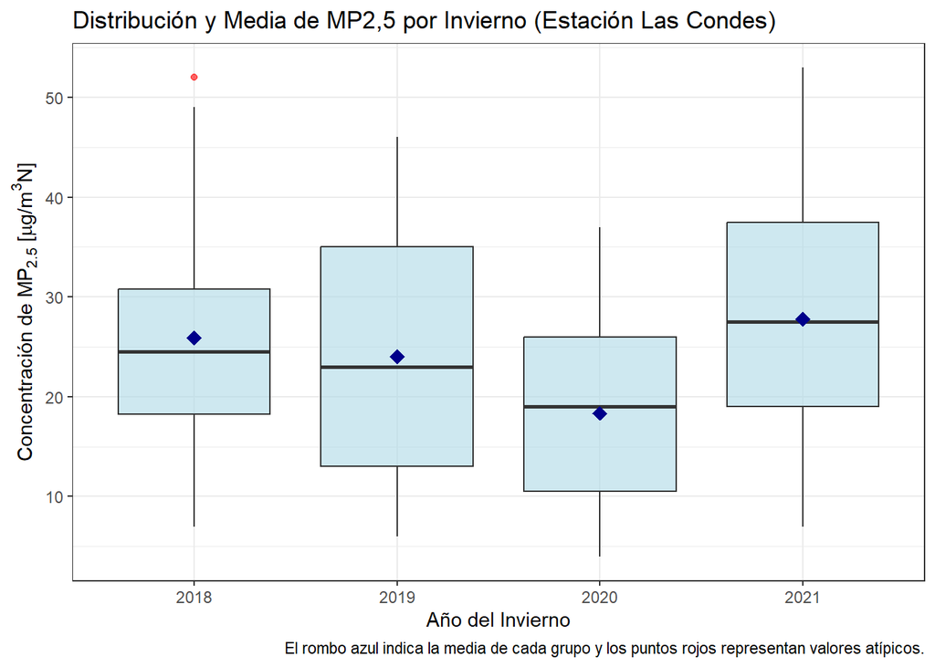

```r
# Gráfico descriptivo de los datos y medias muestrales
ggplot(datos_p1, aes(x = invierno, y = mp25)) +
    geom_boxplot(fill = "lightblue", alpha = 0.6, outlier.color = "red") +
    stat_summary(fun = mean, geom = "point", shape = 18, size = 3.5, color = "darkblue") +
    labs(
        title = "Distribución y Media de MP2,5 por Invierno (Estación Las Condes)",
        x = "Año del Invierno",
        y = expression(paste("Concentración de ", MP[2.5], " [", mu, "g/", m^3, "N]")),
        caption = "El rombo azul indica la media de cada grupo y los puntos rojos representan valores atípicos."
    ) +
    theme_bw()
```

```r
# Comprobar normalidad por grupos para la Pregunta 1
tapply(datos_p1$mp25, datos_p1$invierno, shapiro.test)
```

```
## $`2018`
##
##  Shapiro-Wilk normality test
##
## data:  X[[i]]
## W = 0.96198, p-value = 0.5303
##
##
## $`2019`
##
##  Shapiro-Wilk normality test
##
## data:  X[[i]]
## W = 0.93915, p-value = 0.2097
##
##
## $`2020`
##
##  Shapiro-Wilk normality test
##
## data:  X[[i]]
## W = 0.94669, p-value = 0.2495
##
##
## $`2021`
##
##  Shapiro-Wilk normality test
##
## data:  X[[i]]
## W = 0.96756, p-value = 0.6546
```

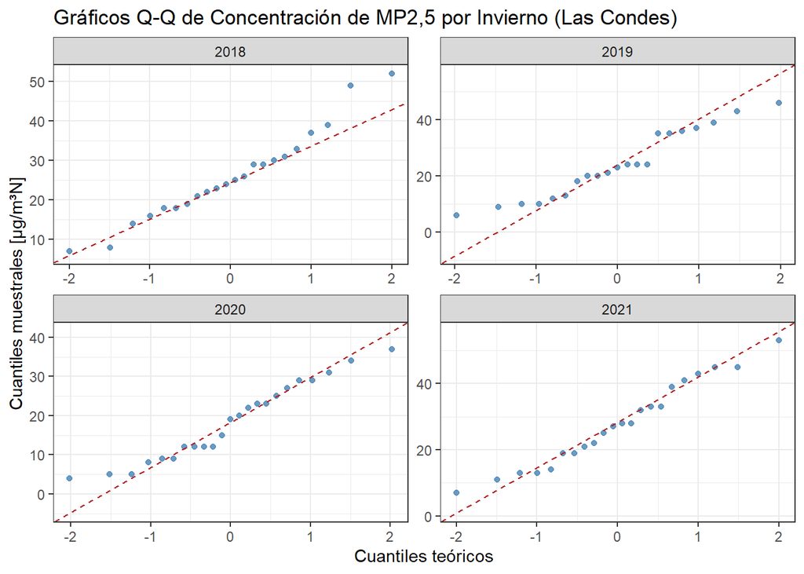

```r
# Gráfico Q-Q para cada invierno en la estación Las Condes
ggplot(datos_p1, aes(sample = mp25)) +
    stat_qq(color = "steelblue", alpha = 0.8) +
    stat_qq_line(color = "firebrick", linetype = "dashed") +
    facet_wrap(~invierno, scales = "free") +
    labs(
        title = "Gráficos Q-Q de Concentración de MP2,5 por Invierno (Las Condes)",
        x = "Cuantiles teóricos",
        y = "Cuantiles muestrales [µg/m³N]"
    ) +
    theme_bw()
```

Gracias a la prueba de Shapiro-Wilk y el grafico Q-Q plot, confirmamos que se cumplen las condiciones de normalidad.

```r
# Prueba de Levene para Pregunta 1
LeveneTest(mp25 ~ invierno, data = datos_p1)
```

```
## Levene's Test for Homogeneity of Variance (center = median)
##       Df F value Pr(>F)
## group  3  0.4048 0.7499
##       84
```

```r
# ANOVA Ómnibus
anova_p1 <- aov(mp25 ~ invierno, data = datos_p1)
summary(anova_p1)
```

```
##             Df Sum Sq Mean Sq F value Pr(>F)
## invierno     3   1128   376.0   2.804 0.0447 *
## Residuals   84  11264   134.1
## ---
## Signif. codes:  0 '***' 0.001 '**' 0.01 '*' 0.05 '.' 0.1 ' ' 1
```

```r
# Contraste de Scheffé (2020 vs Promedio del resto)
# Niveles ordenados: 2018, 2019, 2020, 2021
# Pesos del contraste: -1/3, -1/3, 1, -1/3
contraste_2020 <- matrix(c(-1 / 3, -1 / 3, 1, -1 / 3), ncol = 1)
ScheffeTest(anova_p1, contrasts = contraste_2020)
```

```
##
##   Posthoc multiple comparisons of means: Scheffe Test
##     95% family-wise confidence level
##
## $invierno
##                          diff    lwr.ci   upr.ci   pval
## 2020-2018,2019,2021 -7.561986 -15.57795 0.453974 0.0722 .
##
## ---
## Signif. codes:  0 '***' 0.001 '**' 0.01 '*' 0.05 '.' 0.1 ' ' 1
```

```r
# Comparaciones por pares con Holm
pairwise.t.test(datos_p1$mp25, datos_p1$invierno, p.adjust.method = "holm", pool.sd = TRUE)
```

```
##
##  Pairwise comparisons using t tests with pooled SD
##
## data:  datos_p1$mp25 and datos_p1$invierno
##
##      2018  2019  2020
## 2019 1.000 -     -
## 2020 0.157 0.427 -
## 2021 1.000 0.884 0.046
##
## P value adjustment method: holm
```

### Conclusiones de la Pregunta 1

Tras verificar que se cumplen las condiciones estadísticas (con valores *p* de Shapiro y Levene mayores a 0.05), realizamos el ANOVA y obtuvimos un valor *p* de 0.0447. Como este valor es menor al nivel de significación $\alpha = 0.05$, se rechaza la hipótesis nula (dato que es apoyado visualmente en el gráfico de cajas y medias muestrales). Por lo tanto, sí corresponde aplicar el procedimiento *post-hoc*, ya que existen diferencias significativas entre al menos un par de inviernos.

Al analizar el contraste específico de Scheffé (2020 contra el promedio de 2018, 2019 y 2021), evaluamos si ese año en particular fue distinto globalmente al resto. Por otro lado, al revisar las comparaciones por pares con la corrección de Holm (requerida por el enunciado), notamos que el único par con una diferencia estadísticamente significativa ($p < 0.05$) es 2020 frente a 2021.

En cuanto al contexto, concluimos que la concentración de $\text{MP}_{2,5}$ en la estación Las Condes no se mantuvo igual en todos los inviernos analizados. Específicamente, el año 2020 (marcado por las cuarentenas) registró niveles de contaminación significativamente más bajos que el invierno de 2021, aunque no encontramos evidencia estadística suficiente para afirmar que haya diferido del promedio general de los demás años analizados.

## Pregunta 2

En el invierno de 2022, ¿la concentración diaria promedio de MP2,5 fue la misma en las estaciones Cerro Navia, La Florida y Quilicura? Es un primer análisis exploratorio: interesa identificar qué pares de estaciones merecen un estudio más detallado, en el que se descartarán los falsos positivos. Si filtraron bien los datos, deberían obtener: Cerro Navia, n = 23 y media 47,74; La Florida, n = 23 y media 44,74; Quilicura, n = 23 y media 45,00 [µg/m³N].

### Qué prueba vamos a usar

ANOVA de una vía para muestras independientes porque comparamos la media de una variable continua en tres grupos independientes categóricos.

### Condiciones

- **Independencia:** Se asume por el muestreo aleatorio. Si no se cumpliera, el modelo ANOVA de muestras independientes no podria ser aplicado.
- **Normalidad:** Se verificará con Shapiro-Wilk. Si no se cumpliera, tendríamos que recurrir a alguna prueba no parametrica.
- **Homocedasticidad:** Se verificará con Levene. Si no hubiera varianzas iguales, tendríamos que corregir usando un ANOVA de Welch en lugar del estándar.

### Hipótesis

- $H_0$: Las medias de las concentraciones diarias de MP2,5 en las estaciones Cerro Navia, La Florida y Quilicura en el invierno son iguales ($\mu_{CN} = \mu_{LF} = \mu_{Q}$).
- $H_A$: Al menos una de las medias es diferente.

### Procedimiento Post-Hoc

El procedimiento a utilizar será Fisher (pruebas T sin ajuste). Como el enunciado recalca que es un análisis “exploratorio” y que los falsos positivos “se descartarán en un estudio más detallado”, no es pertinente usar métodos conservadores (como Tukey o Holm) que aumenten el riesgo de falsos negativos. Fisher maximiza la sensibilidad estadística.

### Implementación en R

```r
datos_p2 <- datos %>%
    filter(invierno == 2022, estacion %in% c("Cerro Navia", "La Florida", "Quilicura")) %>%
    mutate(estacion = as.factor(estacion))
```

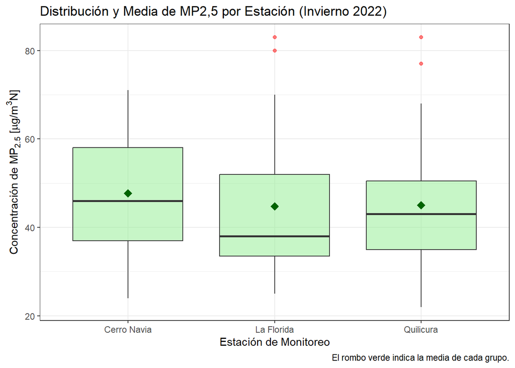

```r
# Gráfico descriptivo de los datos y medias muestrales
ggplot(datos_p2, aes(x = estacion, y = mp25)) +
    geom_boxplot(fill = "lightgreen", alpha = 0.5, outlier.color = "red") +
    stat_summary(fun = mean, geom = "point", shape = 18, size = 3.5, color = "darkgreen") +
    labs(
        title = "Distribución y Media de MP2,5 por Estación (Invierno 2022)",
        x = "Estación de Monitoreo",
        y = expression(paste("Concentración de ", MP[2.5], " [", mu, "g/", m^3, "N]")),
        caption = "El rombo verde indica la media de cada grupo."
    ) +
    theme_bw()
```

```r
# Comprobar normalidad por grupos para la Pregunta 2
tapply(datos_p2$mp25, datos_p2$estacion, shapiro.test)
```

```
## $`Cerro Navia`
##
##  Shapiro-Wilk normality test
##
## data:  X[[i]]
## W = 0.95249, p-value = 0.3293
##
##
## $`La Florida`
##
##  Shapiro-Wilk normality test
##
## data:  X[[i]]
## W = 0.86017, p-value = 0.004184
##
##
## $Quilicura
##
##  Shapiro-Wilk normality test
##
## data:  X[[i]]
## W = 0.93418, p-value = 0.1347
```

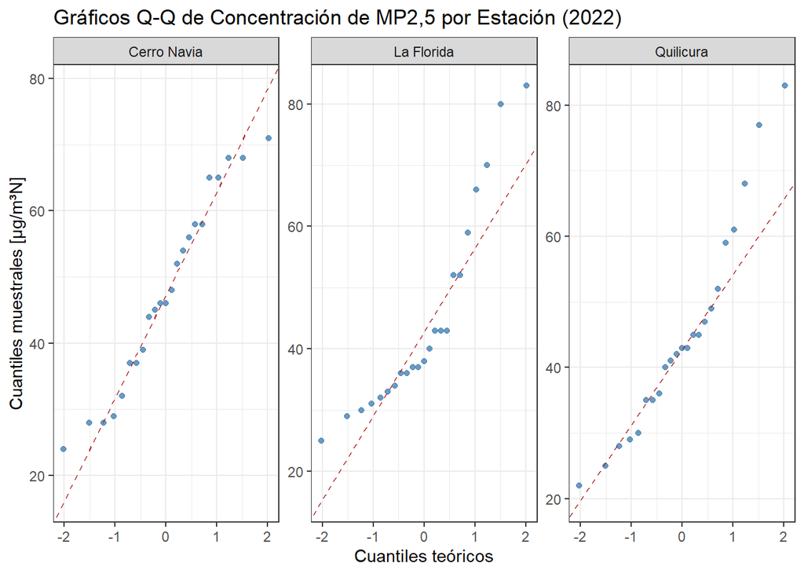

```r
# Gráfico Q-Q para cada estación en el invierno de 2022
ggplot(datos_p2, aes(sample = mp25)) +
    stat_qq(color = "steelblue", alpha = 0.8) +
    stat_qq_line(color = "firebrick", linetype = "dashed") +
    facet_wrap(~estacion, scales = "free") +
    labs(
        title = "Gráficos Q-Q de Concentración de MP2,5 por Estación (2022)",
        x = "Cuantiles teóricos",
        y = "Cuantiles muestrales [µg/m³N]"
    ) +
    theme_bw()
```

A partir de los resultados de Shapiro-Wilk, notamos que Cerro Navia y Quilicura cumplen con la normalidad. Sin embargo, La Florida no cumple este supuesto (p = 0.0042), lo que también se refleja en su gráfico Q-Q. A pesar de esto, como las tres estaciones tienen exactamente el mismo tamaño de muestra (n = 23), el ANOVA resulta ser bastante robusto frente a esta desviación. Por esta razón, y sumado a que la prueba de Levene sí nos validó la homocedasticidad, decidimos continuar con el ANOVA estándar en lugar de pasar a una prueba no paramétrica como Kruskal-Wallis.

```r
# Prueba de Levene para Pregunta 2
LeveneTest(mp25 ~ estacion, data = datos_p2)
```

```
## Levene's Test for Homogeneity of Variance (center = median)
##       Df F value Pr(>F)
## group  2  0.0061 0.9939
##       66
```

```r
# ANOVA Ómnibus
anova_p2 <- aov(mp25 ~ estacion, data = datos_p2)
summary(anova_p2)
```

```
##             Df Sum Sq Mean Sq F value Pr(>F)
## estacion     2    127   63.52   0.261  0.771
## Residuals   66  16041  243.04
```

```r
# Post-hoc sin ajuste (Fisher LSD para estudio exploratorio)
pairwise.t.test(datos_p2$mp25, datos_p2$estacion, p.adjust.method = "none", pool.sd = TRUE)
```

```
##
##  Pairwise comparisons using t tests with pooled SD
##
## data:  datos_p2$mp25 and datos_p2$estacion
##
##            Cerro Navia La Florida
## La Florida 0.52        -
## Quilicura  0.55        0.95
##
## P value adjustment method: none
```

```r
# Comparaciones por pares con Holm (Requerido por enunciado)
pairwise.t.test(datos_p2$mp25, datos_p2$estacion, p.adjust.method = "holm", pool.sd = TRUE)
```

```
##
##  Pairwise comparisons using t tests with pooled SD
##
## data:  datos_p2$mp25 and datos_p2$estacion
##
##            Cerro Navia La Florida
## La Florida 1           -
## Quilicura  1           1
##
## P value adjustment method: holm
```

### Conclusiones de la Pregunta 2

Según los resultados de la prueba ómnibus ($p > 0,05$), no existe evidencia estadística suficiente para rechazar la hipótesis nula. Esto significa que no podemos afirmar que haya diferencias en la concentración de $\text{MP}_{2,5}$ entre las tres estaciones durante el invierno de 2022 (lo cual, en concordancia con el gráfico de cajas, donde se observa una alta superposición en las distribuciones y una notable cercanía entre los promedios de las tres estaciones, respalda esto).

Al no encontrar diferencias globales, técnicamente no corresponde aplicar un procedimiento *post-hoc*. De todos modos, para cumplir con el enunciado, realizamos el análisis exploratorio con Fisher y lo comparamos con el ajuste de Holm.

En la práctica, ambos métodos llegan a la misma conclusión: no hay diferencias significativas entre ningún par de estaciones. La diferencia está en cómo manejan los valores *p*. Holm castiga estos valores para controlar los falsos positivos (acercándolos a 1), siendo mucho más conservador, mientras que Fisher no hace ajustes y entrega valores *p* más bajos. Sin embargo, en este caso, ni siquiera el método de Fisher logró detectar diferencias bajo el umbral de 0,05.

### Corrección pregunta 2

Al finalizar la actividad nos dimos cuenta como grupo que nuestro analisis de la pregunta 2 fue errado, utilizando ANOVA independiente cuando no lo era, por eso, aqui esta la corrección:

## Pregunta 2 - corregida

En el invierno de 2022, ¿la concentración diaria promedio de MP2,5 fue la misma en las estaciones Cerro Navia, La Florida y Quilicura? Es un primer análisis exploratorio: interesa identificar qué pares de estaciones merecen un estudio más detallado, en el que se descartarán los falsos positivos. Si filtraron bien los datos, deberían obtener: Cerro Navia, n = 23 y media 47,74; La Florida, n = 23 y media 44,74; Quilicura, n = 23 y media 45,00 [µg/m³N].

### Qué prueba vamos a usar

ANOVA de medidas repetidas, con post-hoc poco conservador debido a que las 3 estaciones miden los mismos dias del mismo invierno, donde cada dia funciona como un sujeto y se mide en las 3 estaciones

### Condiciones

- **Escala continua:** La concentración de $\text{MP}_{2,5}$ $[\mu\text{g/m}^3\text{N}]$ es cuantitativa continua de razón.
- **Independencia entre casos:** Las observaciones provienen de 23 fechas distintas; se asume suficiente separación temporal para descartar autocorrelación serial climática.
- **Normalidad de las diferencias:** Las diferencias diarias entre pares de estaciones deben distribuirse normalmente, lo que se evalúa con Shapiro-Wilk y gráficos Q-Q.
- **Esfericidad:** Las varianzas de las diferencias entre pares de estaciones deben ser homogéneas, verificado mediante la prueba de Mauchly. Si no se cumple ($p < \alpha$), se infla el error tipo I y se deben corregir los grados de libertad de $F$ con Greenhouse-Geisser o Huynh-Feldt.

### Hipótesis

- $H_0$: En promedio, no existen diferencias entre las concentraciones de MP2,5 que registran las estaciones para un mismo día. Es decir, para todo par $X, Y \in \{\text{Cerro Navia}, \text{La Florida}, \text{Quilicura}\}$, se cumple que $\mu_{d_{X-Y}} = 0$.
- $H_A$: La media de las diferencias entre las concentraciones de dos estaciones para un mismo día es distinta de cero para al menos un par.

### Procedimiento Post-Hoc

Se selecciona el procedimiento de mínima diferencia significativa de Fisher (Fisher LSD pareado), consistente en pruebas $t$ pareadas sin ajuste en los valores $p$ (p.adjust.method = “none”). Como el enunciado señala expresamente que se trata de un estudio exploratorio y que los falsos positivos se descartarán en una etapa posterior más exhaustiva, se prioriza minimizar la tasa de falsos negativos (aumentando la potencia estadística para detectar cualquier indicio de diferencia), descartando métodos conservadores como Tukey o Bonferroni.

### Implementación en R

```r
# 1. Filtrar los datos para el invierno de 2022 y las tres estaciones de interés
datos_p2 <- datos %>%
    filter(invierno == 2022, estacion %in% c("Cerro Navia", "La Florida", "Quilicura")) %>%
    mutate(
        estacion = as.factor(estacion),
        dia = as.factor(fecha)
    )

# Verificación de filtrado según valores de control del enunciado
datos_p2 %>%
    group_by(estacion) %>%
    summarise(
        n = n(),
        media = round(mean(mp25), 2)
    )
```

```
## # A tibble: 3 × 3
##   estacion        n media
##   <fct>       <int> <dbl>
## 1 Cerro Navia    23  47.7
## 2 La Florida     23  44.7
## 3 Quilicura      23  45
```

```r
# 2. Reestructurar a formato ancho para calcular las diferencias pareadas por día
datos_p2_anchos <- datos_p2 %>%
    select(dia, estacion, mp25) %>%
    pivot_wider(names_from = estacion, values_from = mp25) %>%
    rename(CN = `Cerro Navia`, LF = `La Florida`, Q = `Quilicura`) %>%
    mutate(
        `CN - LF` = CN - LF,
        `CN - Q`  = CN - Q,
        `LF - Q`  = LF - Q
    )

# Formato largo de las diferencias para análisis gráfico y Shapiro-Wilk
diferencias_largas <- datos_p2_anchos %>%
    pivot_longer(
        cols = c(`CN - LF`, `CN - Q`, `LF - Q`),
        names_to = "Par",
        values_to = "Diferencia"
    ) %>%
    mutate(Par = as.factor(Par))
```

```r
# 3. Comprobación de normalidad sobre las diferencias pareadas
diferencias_largas %>%
    group_by(Par) %>%
    shapiro_test(Diferencia)
```

```
## # A tibble: 3 × 4
##   Par     variable   statistic     p
##   <fct>   <chr>          <dbl> <dbl>
## 1 CN - LF Diferencia     0.977 0.858
## 2 CN - Q  Diferencia     0.966 0.584
## 3 LF - Q  Diferencia     0.973 0.764
```

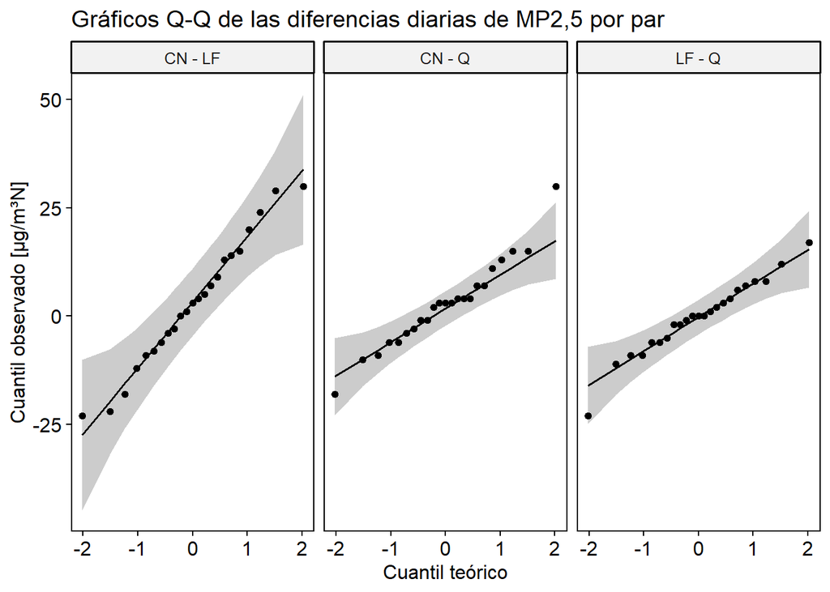

```r
# 4. Gráficos Q-Q de las diferencias entre pares de estaciones
ggqqplot(
    diferencias_largas,
    x = "Diferencia",
    facet.by = "Par",
    palette = c("steelblue", "steelblue1", "steelblue4"),
    xlab = "Cuantil teórico",
    ylab = "Cuantil observado [µg/m³N]",
    title = "Gráficos Q-Q de las diferencias diarias de MP2,5 por par"
)
```

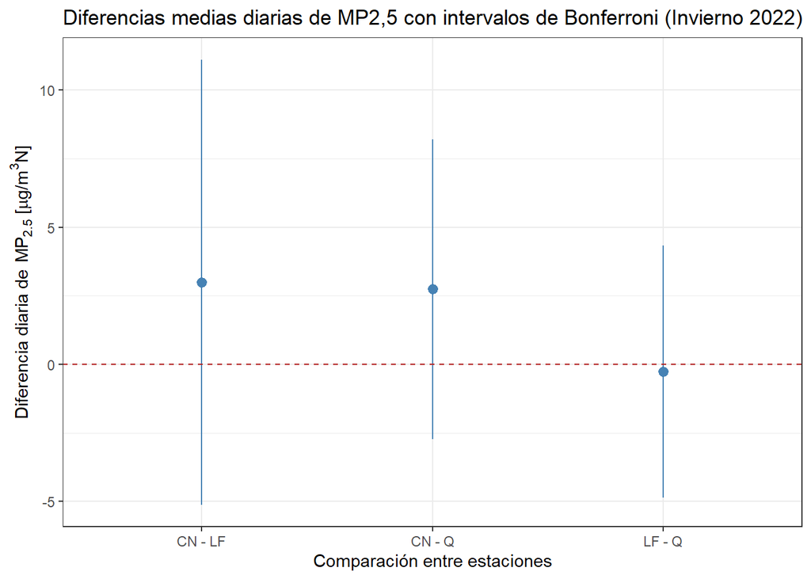

```r
# 5. Gráfico descriptivo e inferencial pertinente (Diferencias pareadas e Intervalos de Confianza)
m_p2 <- choose(nlevels(datos_p2$estacion), 2)
alfa_p2 <- 0.05

ggerrorplot(
    diferencias_largas,
    x = "Par",
    y = "Diferencia",
    desc_stat = "mean_ci",
    ci = 1 - alfa_p2 / m_p2,
    color = "steelblue",
    xlab = "Comparación entre estaciones",
    title = "Diferencias medias diarias de MP2,5 con intervalos de Bonferroni (Invierno 2022)"
) +
    labs(y = expression(paste("Diferencia diaria de ", MP[2.5], " [", mu, "g/", m^3, "N]"))) +
    geom_hline(yintercept = 0, linetype = "dashed", color = "firebrick") +
    theme_bw()
```

```r
# 6. Ejecución del ANOVA ómnibus de medidas repetidas
anova_p2 <- anova_test(
    data = datos_p2,
    dv = mp25,
    wid = dia,
    within = estacion,
    detailed = TRUE
)
print(anova_p2)
```

```
## ANOVA Table (type III tests)
##
## $ANOVA
##        Effect DFn DFd        SSn      SSd       F        p p<.05   ges
## 1 (Intercept)   1  22 144902.087 13104.58 243.262 2.23e-13     * 0.900
## 2    estacion   2  44    127.043  2936.29   0.952 3.94e-01       0.008
##
## $`Mauchly's Test for Sphericity`
##     Effect     W       p p<.05
## 1 estacion 0.505 0.00076     *
##
## $`Sphericity Corrections`
##     Effect   GGe      DF[GG] p[GG] p[GG]<.05   HFe      DF[HF] p[HF] p[HF]<.05
## 1 estacion 0.669 1.34, 29.42 0.364           0.696 1.39, 30.62 0.367
```

```r
# 7. Procedimiento post hoc exploratorio (Fisher LSD pareado sin corrección)
post_fisher <- pairwise_t_test(
    data = datos_p2,
    formula = mp25 ~ estacion,
    paired = TRUE,
    p.adjust.method = "none",
    detailed = TRUE
)
print(post_fisher, width = Inf)
```

```
## # A tibble: 3 × 15
##   estimate .y.   group1      group2        n1    n2 statistic     p    df
## *    <dbl> <chr> <chr>       <chr>      <int> <int>     <dbl> <dbl> <dbl>
## 1    3     mp25  Cerro Navia La Florida    23    23     0.957 0.349    22
## 2    2.74  mp25  Cerro Navia Quilicura     23    23     1.30  0.207    22
## 3   -0.261 mp25  La Florida  Quilicura     23    23    -0.147 0.884    22
##   conf.low conf.high method        alternative p.adj p.adj.signif
## *    <dbl>     <dbl> <chr>         <chr>       <dbl> <chr>
## 1    -3.50      9.50 Paired t-test two.sided   0.349 ns
## 2    -1.63      7.11 Paired t-test two.sided   0.207 ns
## 3    -3.94      3.42 Paired t-test two.sided   0.884 ns
```

```r
# 8. Comparaciones por pares con corrección de Holm pareada
post_holm <- pairwise_t_test(
    data = datos_p2,
    formula = mp25 ~ estacion,
    paired = TRUE,
    p.adjust.method = "holm",
    detailed = TRUE
)
print(post_holm, width = Inf)
```

```
## # A tibble: 3 × 15
##   estimate .y.   group1      group2        n1    n2 statistic     p    df
## *    <dbl> <chr> <chr>       <chr>      <int> <int>     <dbl> <dbl> <dbl>
## 1    3     mp25  Cerro Navia La Florida    23    23     0.957 0.349    22
## 2    2.74  mp25  Cerro Navia Quilicura     23    23     1.30  0.207    22
## 3   -0.261 mp25  La Florida  Quilicura     23    23    -0.147 0.884    22
##   conf.low conf.high method        alternative p.adj p.adj.signif
## *    <dbl>     <dbl> <chr>         <chr>       <dbl> <chr>
## 1    -3.50      9.50 Paired t-test two.sided   0.698 ns
## 2    -1.63      7.11 Paired t-test two.sided   0.622 ns
## 3    -3.94      3.42 Paired t-test two.sided   0.884 ns
```

### Conclusiones de la Pregunta 2

Con dicha corrección, la prueba ómnibus arroja un estadístico F(1,39; 30,62) = 0,952 con un valor p = 0,367. Dado que p > 0,05, no existe evidencia estadística suficiente para rechazar la hipótesis nula, concluyéndose que no se observan diferencias significativas globales entre estaciones. Por regla metodológica formal, al no ser significativa la prueba ómnibus, no corresponde aplicar un procedimiento post hoc.

No obstante, al realizar las comparaciones pareadas con fines exploratorios, el procedimiento de Fisher LSD no detecta diferencias significativas en ningún par (CN vs LF: p = 0,349; CN vs Q: p = 0,207; LF vs Q: p = 0,884). Al aplicar la corrección de Holm, los valores p se penalizan y aumentan (0,698; 0,622 y 0,884 respectivamente), manteniendo la misma conclusión. Visualmente, el gráfico de diferencias medias confirma esta situación, pues los intervalos de Bonferroni de todos los pares abarcan holgadamente el cero.

Por lo tanto, se concluye con un 95% de confianza que no hay evidencia para afirmar que la concentración diaria de MP2,5 haya sido distinta entre Cerro Navia, La Florida y Quilicura en el invierno de 2022.